# CME538 - Introduction to Data Science

# Setup Notebook

```python
# Import 3rd party libraries
import os
import json
import numpy as np
import datetime as dt
import codecs
import requests
import pandas as pd
import seaborn as sns
import matplotlib.pylab as plt
from io import StringIO
from fuzzywuzzy import fuzz

# Configure Notebook
%matplotlib inline
plt.style.use('fivethirtyeight')
sns.set_context("notebook")
import warnings
warnings.filterwarnings('ignore')
```

# Data Cleaning

## Weather Data

### Load Weather Data

```python
# Set weather data path
path_weather = os.path.join(os.path.abspath(os.getcwd()), 'data', 'weather')

# Get weather file names
weather_filenames = [filename for filename in os.listdir(path_weather) if 'climate' in filename]

# Print file names
print(weather_filenames[0:5])
```

```
['en_climate_hourly_ON_6158359_01-2018_P1H.csv', 'en_climate_hourly_ON_6158359_01-2019_P1H.csv', 'en_climate_hourly_ON_6158359_01-2020_P1H.csv', 'en_climate_hourly_ON_6158359_01-2021_P1H.csv', 'en_climate_hourly_ON_6158359_01-2022_P1H.csv']
```

```python
# Create a dictionary where key:value pairs correspond to the file name and DataFrame respectively
weather_data = {filename: pd.read_csv(os.path.join(path_weather, filename)) for filename in weather_filenames}
```

```python
weather_rename = {
    'Date/Time (LST)' : 'Date/Time',
    'Time (LST)' : 'Time',
}

for filename in weather_filenames:
    weather_data[filename].rename(columns=weather_rename, inplace=True)
```

```python
# Import weather
weather = pd.concat([weather_data[filename] for filename in weather_filenames], ignore_index=True)

# View DataFrame
weather.head()
```

|  | Longitude (x) | Latitude (y) | Station Name | Climate ID | Date/Time | Year | Month | Day | Time | Temp (°C) | ... | Visibility Flag | Stn Press (kPa) | Stn Press Flag | Hmdx | Hmdx Flag | Wind Chill | Wind Chill Flag | Weather | Precip. Amount (mm) | Precip. Amount Flag |
| --- | --- | --- | --- | --- | --- | --- | --- | --- | --- | --- | --- | --- | --- | --- | --- | --- | --- | --- | --- | --- | --- |
| 0 | -79.4 | 43.63 | TORONTO CITY CENTRE | 6158359 | 2018-01-01 00:00 | 2018 | 1 | 1 | 00:00 | -16.2 | ... | NaN | 102.13 | NaN | NaN | NaN | -22.0 | NaN | NaN | NaN | NaN |
| 1 | -79.4 | 43.63 | TORONTO CITY CENTRE | 6158359 | 2018-01-01 01:00 | 2018 | 1 | 1 | 01:00 | -16.8 | ... | NaN | 102.10 | NaN | NaN | NaN | -20.0 | NaN | NaN | NaN | NaN |
| 2 | -79.4 | 43.63 | TORONTO CITY CENTRE | 6158359 | 2018-01-01 02:00 | 2018 | 1 | 1 | 02:00 | -17.3 | ... | NaN | 102.15 | NaN | NaN | NaN | -26.0 | NaN | NaN | NaN | NaN |
| 3 | -79.4 | 43.63 | TORONTO CITY CENTRE | 6158359 | 2018-01-01 03:00 | 2018 | 1 | 1 | 03:00 | -17.9 | ... | NaN | 102.13 | NaN | NaN | NaN | -24.0 | NaN | NaN | NaN | NaN |
| 4 | -79.4 | 43.63 | TORONTO CITY CENTRE | 6158359 | 2018-01-01 04:00 | 2018 | 1 | 1 | 04:00 | -17.2 | ... | NaN | 102.09 | NaN | NaN | NaN | -21.0 | NaN | NaN | NaN | NaN |

5 rows × 30 columns

```python
weather.info()
```

```
<class 'pandas.core.frame.DataFrame'>
RangeIndex: 43824 entries, 0 to 43823
Data columns (total 30 columns):
 #   Column               Non-Null Count  Dtype
---  ------               --------------  -----
 0   Longitude (x)        43824 non-null  float64
 1   Latitude (y)         43824 non-null  float64
 2   Station Name         43824 non-null  object
 3   Climate ID           43824 non-null  int64
 4   Date/Time            43824 non-null  object
 5   Year                 43824 non-null  int64
 6   Month                43824 non-null  int64
 7   Day                  43824 non-null  int64
 8   Time                 43824 non-null  object
 9   Temp (°C)            43448 non-null  float64
```

[output cut: 22 more lines]

### Drop Redundant Columns

Apart from the unnecessary columns specified in proposal, 'Stn Press (kPa)' is not important because small atmospheric pressure changes have infinitesimal effects on everyday activities.

```python
weather_clean = weather.drop(['Year', 'Month', 'Day', 'Time', 'Station Name', 'Climate ID', 'Longitude (x)', 'Latitude (y)', 'Stn Press (kPa)'], axis=1)
```

- The 'Date/Time' column need to be converted to datetime variable and localized to 'EST' timezone.
- The 'Weather' column is the visual observation of the weather environment and appears to be important. The missing values in this column means a clear weather. So missing values should be assigned with 'Clear'.
- There are a number of columns containing the word 'Flag', and only contains NaN or 'M' values. According to Environment and Climate Change Canada, the 'M' represents 'missing' which means the data is unretrievable or unavailable. The flag columns can be removed since they only contain overlapping information.

```python
# Look for and drop the columns containing the word 'Flag'
flag_columns = [col for col in weather.columns if 'Flag' in col]
weather_clean = weather_clean.drop(flag_columns, axis = 1)
```

### Check on duplicates

```python
weather_clean[weather_clean.duplicated(subset=['Date/Time'])]
```

|  | Date/Time | Temp (°C) | Dew Point Temp (°C) | Rel Hum (%) | Wind Dir (10s deg) | Wind Spd (km/h) | Visibility (km) | Hmdx | Wind Chill | Weather | Precip. Amount (mm) |
| --- | --- | --- | --- | --- | --- | --- | --- | --- | --- | --- | --- |

There is no duplicated weather record.

```python
weather_clean.info()
```

```
<class 'pandas.core.frame.DataFrame'>
RangeIndex: 43824 entries, 0 to 43823
Data columns (total 11 columns):
 #   Column               Non-Null Count  Dtype
---  ------               --------------  -----
 0   Date/Time            43824 non-null  object
 1   Temp (°C)            43448 non-null  float64
 2   Dew Point Temp (°C)  43187 non-null  float64
 3   Rel Hum (%)          43200 non-null  float64
 4   Wind Dir (10s deg)   41367 non-null  float64
 5   Wind Spd (km/h)      43753 non-null  float64
 6   Visibility (km)      43745 non-null  float64
 7   Hmdx                 7219 non-null   float64
 8   Wind Chill           7759 non-null   float64
 9   Weather              6498 non-null   object
 10  Precip. Amount (mm)  18242 non-null  float64
dtypes: float64(9), object(2)
memory usage: 3.7+ MB
```

### Datetime data

```python
# Convert 'Date/Time' column to datetime variables
weather_clean['Date/Time'] = pd.to_datetime(weather_clean['Date/Time']).dt.tz_localize('US/Eastern', ambiguous=True, nonexistent='shift_backward')
```

```python
weather_clean = weather_clean.set_index('Date/Time')
weather_clean.head()
```

| Date/Time | Temp (°C) | Dew Point Temp (°C) | Rel Hum (%) | Wind Dir (10s deg) | Wind Spd (km/h) | Visibility (km) | Hmdx | Wind Chill | Weather | Precip. Amount (mm) |
| --- | --- | --- | --- | --- | --- | --- | --- | --- | --- | --- |
| 2018-01-01 00:00:00-05:00 | -16.2 | -20.5 | 70.0 | 31.0 | 8.0 | 16.1 | NaN | -22.0 | NaN | NaN |
| 2018-01-01 01:00:00-05:00 | -16.8 | -21.1 | 70.0 | NaN | 4.0 | 16.1 | NaN | -20.0 | NaN | NaN |
| 2018-01-01 02:00:00-05:00 | -17.3 | -20.8 | 75.0 | 29.0 | 15.0 | 16.1 | NaN | -26.0 | NaN | NaN |
| 2018-01-01 03:00:00-05:00 | -17.9 | -21.6 | 73.0 | 31.0 | 9.0 | 16.1 | NaN | -24.0 | NaN | NaN |
| 2018-01-01 04:00:00-05:00 | -17.2 | -21.1 | 72.0 | 31.0 | 5.0 | 16.1 | NaN | -21.0 | NaN | NaN |

### Missing Values

```python
# Check missing values
weather_clean.isnull().sum()
```

```
Temp (°C)                376
Dew Point Temp (°C)      637
Rel Hum (%)              624
Wind Dir (10s deg)      2457
Wind Spd (km/h)           71
Visibility (km)           79
Hmdx                   36605
Wind Chill             36065
Weather                37326
Precip. Amount (mm)    25582
dtype: int64
```

'Hmdx', 'Wind Chill', and 'Weather' columns have significantly more missing values than the other columns.

```python
# Check missing values for each year
display(weather_clean.resample('Y').agg(lambda row: row.isnull().sum()))
```

| Date/Time | Temp (°C) | Dew Point Temp (°C) | Rel Hum (%) | Wind Dir (10s deg) | Wind Spd (km/h) | Visibility (km) | Hmdx | Wind Chill | Weather | Precip. Amount (mm) |
| --- | --- | --- | --- | --- | --- | --- | --- | --- | --- | --- |
| 2018-12-31 00:00:00-05:00 | 4 | 4 | 2 | 504 | 2 | 4 | 6979 | 7084 | 7336 | 8760 |
| 2019-12-31 00:00:00-05:00 | 95 | 145 | 145 | 595 | 23 | 24 | 7608 | 6936 | 7213 | 8760 |
| 2020-12-31 00:00:00-05:00 | 13 | 12 | 7 | 426 | 14 | 16 | 7211 | 7599 | 7494 | 8040 |
| 2021-12-31 00:00:00-05:00 | 26 | 52 | 47 | 476 | 21 | 16 | 7307 | 7383 | 7624 | 14 |
| 2022-12-31 00:00:00-05:00 | 238 | 424 | 423 | 456 | 11 | 19 | 7500 | 7063 | 7659 | 8 |

#### **Imputing/filling Hmdx and Wind Chill missing values**

According to Environment and Climate Change Canada (https://climate.weather.gc.ca/glossary_e.html), the humidex values are only reported if:

(1) air temperature is greater than or equal to 20 degrees celsius and,

(2) the humidex value is at least 1 degree greater than the air temperature.

Similarily, wind chill is only calculated if the air temperature is less than or equal to 0 degrees celsius.

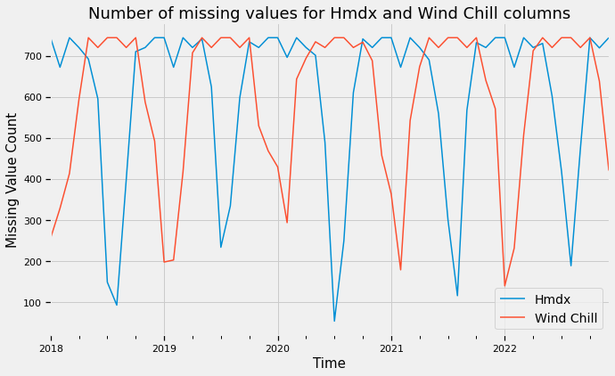

```python
# Visualizing number of missing values in 'Hmdx' and 'Wind Chill' columns
weather_clean.resample('M').agg(lambda row: row.isnull().sum())[['Hmdx', 'Wind Chill']].plot(figsize = (10, 6))

plt.title('Number of missing values for Hmdx and Wind Chill columns', fontsize = 18)
plt.xlabel('Time', fontsize = 15)
plt.ylabel('Missing Value Count', fontsize = 15)
plt.legend(['Hmdx', 'Wind Chill'], fontsize = 14)
```

We can find that there are more missing wind chill values and fewer missing humidex values in the summer, and vice versa in the winter. This agrees with the explanation provided by Environment and Climate Change Canada.

Therefore, the missing values in 'Hmdx' and 'Wind Chill' should not be modified.

#### **Imputing/filling Weather missing values**

```python
weather_clean['Weather'].unique()
```

```
array([nan, 'Snow', 'Fog', 'Rain', 'Rain,Fog', 'Haze', 'Rain,Snow',
       'Moderate Rain', 'Freezing Rain,Fog', 'Snow,Blowing Snow',
       'Heavy Snow', 'Moderate Snow', 'Haze,Blowing Snow',
       'Heavy Rain,Fog', 'Moderate Rain,Fog', 'Freezing Rain,Snow',
       'Freezing Rain', 'Thunderstorms,Rain',
       'Thunderstorms,Moderate Rain,Fog', 'Thunderstorms,Moderate Rain',
       'Thunderstorms', 'Thunderstorms,Heavy Rain,Fog',
       'Thunderstorms,Heavy Rain', 'Thunderstorms,Rain,Fog',
       'Thunderstorms,Fog'], dtype=object)
```

The weather feature contains weather phenomenon, and therefore the NaN values should represent a clear day. We can fill the missing values using "Clear" str.

```python
# Modifying missing values in 'Weather' column
weather_clean['Weather'].fillna('Clear', inplace = True)
weather_clean.head()
```

| Date/Time | Temp (°C) | Dew Point Temp (°C) | Rel Hum (%) | Wind Dir (10s deg) | Wind Spd (km/h) | Visibility (km) | Hmdx | Wind Chill | Weather | Precip. Amount (mm) |
| --- | --- | --- | --- | --- | --- | --- | --- | --- | --- | --- |
| 2018-01-01 00:00:00-05:00 | -16.2 | -20.5 | 70.0 | 31.0 | 8.0 | 16.1 | NaN | -22.0 | Clear | NaN |
| 2018-01-01 01:00:00-05:00 | -16.8 | -21.1 | 70.0 | NaN | 4.0 | 16.1 | NaN | -20.0 | Clear | NaN |
| 2018-01-01 02:00:00-05:00 | -17.3 | -20.8 | 75.0 | 29.0 | 15.0 | 16.1 | NaN | -26.0 | Clear | NaN |
| 2018-01-01 03:00:00-05:00 | -17.9 | -21.6 | 73.0 | 31.0 | 9.0 | 16.1 | NaN | -24.0 | Clear | NaN |
| 2018-01-01 04:00:00-05:00 | -17.2 | -21.1 | 72.0 | 31.0 | 5.0 | 16.1 | NaN | -21.0 | Clear | NaN |

#### **Imputing/filling missing values for other columns**

The weather data is sampled every hour, so it should be reasonable to impute missing values based on the time-adjacent valid observations. Except for 'Hmdx', 'Wind Chill', and 'Weather' columns, all other columns will have missing values filled using linear interpolation between valid observations.

```python
# Linear interpolating values
interpolating_col = weather_clean.columns.drop(['Hmdx', 'Wind Chill', 'Weather'])
weather_clean[interpolating_col] = weather_clean[interpolating_col].interpolate(
    method = 'linear', axis = 0, limit_direction = 'both').round(1)
```

```python
# Check if there are still missing values
weather_clean.isnull().sum()
```

```
Temp (°C)                  0
Dew Point Temp (°C)        0
Rel Hum (%)                0
Wind Dir (10s deg)         0
Wind Spd (km/h)            0
Visibility (km)            0
Hmdx                   36605
Wind Chill             36065
Weather                    0
Precip. Amount (mm)        0
dtype: int64
```

### Outliers

Check if there are outliers for temperature.

```python
weather_clean.describe()
```

|  | Temp (°C) | Dew Point Temp (°C) | Rel Hum (%) | Wind Dir (10s deg) | Wind Spd (km/h) | Visibility (km) | Hmdx | Wind Chill | Precip. Amount (mm) |
| --- | --- | --- | --- | --- | --- | --- | --- | --- | --- |
| count | 43824.000000 | 43824.000000 | 43824.000000 | 43824.00000 | 43824.000000 | 43824.000000 | 7219.000000 | 7759.000000 | 43824.000000 |
| mean | 9.346185 | 4.419959 | 72.747399 | 19.93661 | 17.319665 | 15.123866 | 29.641779 | -10.910555 | 0.045562 |
| std | 9.918031 | 10.230561 | 15.154699 | 9.90149 | 10.200704 | 3.071844 | 3.221130 | 5.406902 | 0.331574 |
| min | -21.900000 | -28.400000 | 16.000000 | 1.00000 | 0.000000 | 0.000000 | 25.000000 | -36.000000 | 0.000000 |
| 25% | 1.700000 | -3.000000 | 63.000000 | 8.95000 | 9.000000 | 16.100000 | 27.000000 | -14.000000 | 0.000000 |
| 50% | 8.600000 | 4.000000 | 74.000000 | 22.00000 | 15.000000 | 16.100000 | 29.000000 | -10.000000 | 0.000000 |
| 75% | 18.300000 | 13.100000 | 84.000000 | 28.00000 | 22.000000 | 16.100000 | 32.000000 | -7.000000 | 0.000000 |
| max | 34.100000 | 24.700000 | 100.000000 | 36.00000 | 76.000000 | 16.100000 | 43.000000 | -1.000000 | 18.200000 |

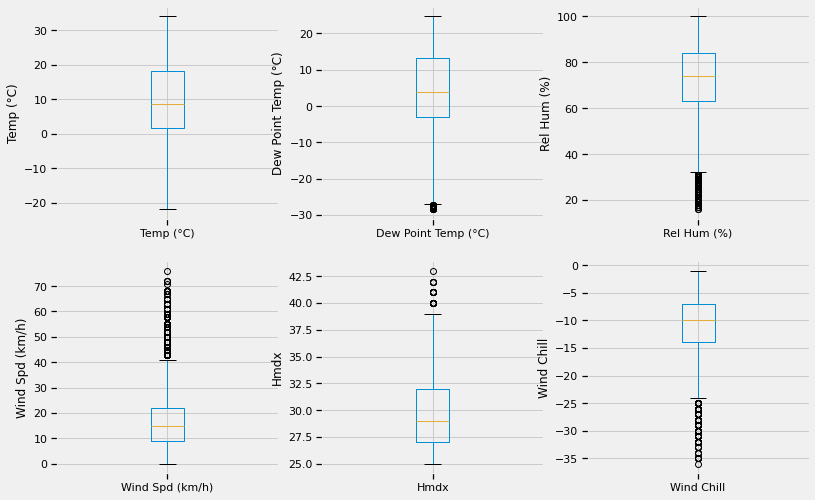

```python
# draw boxplots to visualize outliers
plt.figure(figsize=(12,8))
outlier_columns = [
    'Temp (°C)', 'Dew Point Temp (°C)', 'Rel Hum (%)',
    'Wind Spd (km/h)', 'Hmdx', 'Wind Chill'
    ]

for i, feature in enumerate(outlier_columns):
    plt.subplot(2,3,i+1)
    fig = weather_clean.boxplot(column=outlier_columns[i])
    fig.set_ylabel(feature)

plt.show()
```

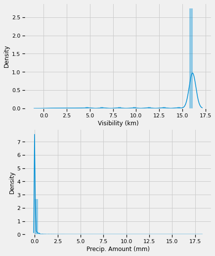

```python
# draw distplot to visualize outliers
plt.figure(figsize=(6,8))
other_columns = ['Visibility (km)', 'Precip. Amount (mm)']
plt.subplot(2,1,1)
sns.distplot(weather_clean[other_columns[0]])
plt.subplot(2,1,2)
sns.distplot(weather_clean[other_columns[1]])
plt.show()
```

- Wind Dir (10s deg) should not be checked for outliers since this represent the direction of wind.
- There is no outlier for 'Temp (°C)', which means the weather records are rather reliable.
- The outliers for 'Dew Point Temp (°C)', 'Rel Hum (%)', 'Wind Spd (km/h)', 'Hmdx', 'Wind Chill' actually represents extreme weather condition and should not be removed or capped.
- Visibility and Precip. Amount features distribution tells that most of the days are clear and without precipitation. And the outliers also represents extreme weather condition. So they should not be removed or capped.

**Conclusion:** There is no need to remove outliers. The weather data is cleaned! Note that the NaN value for Wind Chill and Hmdx should not be treated as a simple zero.

```python
weather_clean.info()
```

```
<class 'pandas.core.frame.DataFrame'>
DatetimeIndex: 43824 entries, 2018-01-01 00:00:00-05:00 to 2022-12-31 23:00:00-05:00
Data columns (total 10 columns):
 #   Column               Non-Null Count  Dtype
---  ------               --------------  -----
 0   Temp (°C)            43824 non-null  float64
 1   Dew Point Temp (°C)  43824 non-null  float64
 2   Rel Hum (%)          43824 non-null  float64
 3   Wind Dir (10s deg)   43824 non-null  float64
 4   Wind Spd (km/h)      43824 non-null  float64
 5   Visibility (km)      43824 non-null  float64
 6   Hmdx                 7219 non-null   float64
 7   Wind Chill           7759 non-null   float64
 8   Weather              43824 non-null  object
 9   Precip. Amount (mm)  43824 non-null  float64
dtypes: float64(9), object(1)
memory usage: 3.7+ MB
```

```python
unique_values = weather_clean['Weather'].unique()

print(unique_values)
```

```
['Clear' 'Snow' 'Fog' 'Rain' 'Rain,Fog' 'Haze' 'Rain,Snow' 'Moderate Rain'
 'Freezing Rain,Fog' 'Snow,Blowing Snow' 'Heavy Snow' 'Moderate Snow'
 'Haze,Blowing Snow' 'Heavy Rain,Fog' 'Moderate Rain,Fog'
 'Freezing Rain,Snow' 'Freezing Rain' 'Thunderstorms,Rain'
 'Thunderstorms,Moderate Rain,Fog' 'Thunderstorms,Moderate Rain'
 'Thunderstorms' 'Thunderstorms,Heavy Rain,Fog' 'Thunderstorms,Heavy Rain'
 'Thunderstorms,Rain,Fog' 'Thunderstorms,Fog']
```

```python
weather_clean
```

| Date/Time | Temp (°C) | Dew Point Temp (°C) | Rel Hum (%) | Wind Dir (10s deg) | Wind Spd (km/h) | Visibility (km) | Hmdx | Wind Chill | Weather | Precip. Amount (mm) |
| --- | --- | --- | --- | --- | --- | --- | --- | --- | --- | --- |
| 2018-01-01 00:00:00-05:00 | -16.2 | -20.5 | 70.0 | 31.0 | 8.0 | 16.1 | NaN | -22.0 | Clear | 0.0 |
| 2018-01-01 01:00:00-05:00 | -16.8 | -21.1 | 70.0 | 30.0 | 4.0 | 16.1 | NaN | -20.0 | Clear | 0.0 |
| 2018-01-01 02:00:00-05:00 | -17.3 | -20.8 | 75.0 | 29.0 | 15.0 | 16.1 | NaN | -26.0 | Clear | 0.0 |
| 2018-01-01 03:00:00-05:00 | -17.9 | -21.6 | 73.0 | 31.0 | 9.0 | 16.1 | NaN | -24.0 | Clear | 0.0 |
| 2018-01-01 04:00:00-05:00 | -17.2 | -21.1 | 72.0 | 31.0 | 5.0 | 16.1 | NaN | -21.0 | Clear | 0.0 |
| ... | ... | ... | ... | ... | ... | ... | ... | ... | ... | ... |
| 2022-12-31 19:00:00-05:00 | 6.2 | 5.5 | 95.0 | 33.0 | 24.0 | 16.1 | NaN | NaN | Rain | 0.0 |
| 2022-12-31 20:00:00-05:00 | 5.4 | 3.9 | 90.0 | 32.0 | 26.0 | 16.1 | NaN | NaN | Clear | 0.0 |
| 2022-12-31 21:00:00-05:00 | 4.8 | 3.0 | 88.0 | 32.0 | 22.0 | 16.1 | NaN | NaN | Clear | 0.0 |
| 2022-12-31 22:00:00-05:00 | 4.5 | 2.7 | 88.0 | 31.0 | 26.0 | 16.1 | NaN | NaN | Clear | 0.0 |
| 2022-12-31 23:00:00-05:00 | 4.2 | 1.2 | 81.0 | 31.0 | 22.0 | 16.1 | NaN | NaN | Clear | 0.0 |

43824 rows × 10 columns

## Collision Data

```python
collision_data = pd.read_csv('Cyclists.csv')
collision_data
```

|  | X | Y | INDEX_ | ACCNUM | YEAR | DATE | TIME | STREET1 | STREET2 | OFFSET | ... | AG_DRIV | REDLIGHT | ALCOHOL | DISABILITY | HOOD_158 | NEIGHBOURHOOD_158 | HOOD_140 | NEIGHBOURHOOD_140 | DIVISION | ObjectId |
| --- | --- | --- | --- | --- | --- | --- | --- | --- | --- | --- | --- | --- | --- | --- | --- | --- | --- | --- | --- | --- | --- |
| 0 | -8838387.970 | 5418863.036 | 5272001 | 1118994.0 | 2009 | 2009/08/16 04:00:00+00 | 1455 | YONGE ST | CHAPLIN CRES | NaN | ... | NaN | NaN | NaN | NaN | 174 | South Eglinton-Davisville | 104 | Mount Pleasant West (104) | D53 | 1 |
| 1 | -8845389.965 | 5412183.095 | 5388094 | 1050893.0 | 2008 | 2008/07/13 04:00:00+00 | 1220 | BLOOR Stre W | KEELE Stre | NaN | ... | NaN | NaN | NaN | NaN | 88 | High Park North | 88 | High Park North (88) | D11 | 2 |
| 2 | -8815344.390 | 5429554.993 | 7527653 | 1307650.0 | 2012 | 2012/07/27 04:00:00+00 | 2133 | KINGSTON RD | LAWRENCE AVE E | NaN | ... | NaN | NaN | NaN | NaN | 136 | West Hill | 136 | West Hill (136) | D43 | 3 |
| 3 | -8813730.702 | 5430757.287 | 5289851 | 1126624.0 | 2009 | 2009/08/16 04:00:00+00 | 2040 | 4660 KINGSTON Road | NaN | NaN | ... | Yes | NaN | NaN | NaN | 136 | West Hill | 136 | West Hill (136) | D43 | 4 |
| 4 | -8845389.965 | 5412183.095 | 5388095 | 1050893.0 | 2008 | 2008/07/13 04:00:00+00 | 1220 | BLOOR Stre W | KEELE Stre | NaN | ... | NaN | NaN | NaN | NaN | 88 | High Park North | 88 | High Park North (88) | D11 | 5 |
| ... | ... | ... | ... | ... | ... | ... | ... | ... | ... | ... | ... | ... | ... | ... | ... | ... | ... | ... | ... | ... | ... |
| 1901 | -8856145.655 | 5405923.266 | 80497570 | NaN | 2016 | 2016/01/23 05:00:00+00 | 2010 | THE QUEENSWAY | NORTH QUEEN ST | NaN | ... | Yes | NaN | NaN | NaN | 159 | Etobicoke City Centre | 14 | Islington-City Centre West (14) | D22 | 1902 |
| 1902 | -8818851.176 | 5427660.532 | 80499093 | NaN | 2016 | 2016/02/20 05:00:00+00 | 1717 | CONFEDERATION DR | STEVENWOOD RD | NaN | ... | NaN | NaN | NaN | NaN | 141 | Golfdale-Cedarbrae-Woburn | 137 | Woburn (137) | D43 | 1903 |
| 1903 | -8818851.176 | 5427660.532 | 80499094 | NaN | 2016 | 2016/02/20 05:00:00+00 | 1717 | CONFEDERATION DR | STEVENWOOD RD | NaN | ... | NaN | NaN | NaN | NaN | 141 | Golfdale-Cedarbrae-Woburn | 137 | Woburn (137) | D43 | 1904 |
| 1904 | -8843215.896 | 5411582.138 | 80503244 | NaN | 2016 | 2016/03/20 04:00:00+00 | 344 | COLLEGE ST | LANSDOWNE AVE | NaN | ... | Yes | NaN | NaN | NaN | 83 | Dufferin Grove | 83 | Dufferin Grove (83) | D11 | 1905 |
| 1905 | -8843215.896 | 5411582.138 | 80503245 | NaN | 2016 | 2016/03/20 04:00:00+00 | 344 | COLLEGE ST | LANSDOWNE AVE | NaN | ... | Yes | NaN | NaN | NaN | 83 | Dufferin Grove | 83 | Dufferin Grove (83) | D11 | 1906 |

1906 rows × 57 columns

```python
Collision_selected = collision_data[['INDEX_', 'DATE', 'TIME', 'ACCLASS','INJURY']]

# Display the resulting DataFrame with selected columns
Collision_selected
```

|  | INDEX_ | DATE | TIME | ACCLASS | INJURY |
| --- | --- | --- | --- | --- | --- |
| 0 | 5272001 | 2009/08/16 04:00:00+00 | 1455 | Non-Fatal Injury | Minimal |
| 1 | 5388094 | 2008/07/13 04:00:00+00 | 1220 | Non-Fatal Injury | None |
| 2 | 7527653 | 2012/07/27 04:00:00+00 | 2133 | Fatal | NaN |
| 3 | 5289851 | 2009/08/16 04:00:00+00 | 2040 | Non-Fatal Injury | None |
| 4 | 5388095 | 2008/07/13 04:00:00+00 | 1220 | Non-Fatal Injury | Major |
| ... | ... | ... | ... | ... | ... |
| 1901 | 80497570 | 2016/01/23 05:00:00+00 | 2010 | Non-Fatal Injury | Major |
| 1902 | 80499093 | 2016/02/20 05:00:00+00 | 1717 | Non-Fatal Injury | None |
| 1903 | 80499094 | 2016/02/20 05:00:00+00 | 1717 | Non-Fatal Injury | Major |
| 1904 | 80503244 | 2016/03/20 04:00:00+00 | 344 | Non-Fatal Injury | None |
| 1905 | 80503245 | 2016/03/20 04:00:00+00 | 344 | Non-Fatal Injury | Major |

1906 rows × 5 columns

```python
# Assuming you've already read the CSV file into Collision_selected
Collision_selected['DATE'] = pd.to_datetime(Collision_selected['DATE'], utc=True).dt.tz_convert('US/Eastern')
filtered_data = Collision_selected[(Collision_selected['DATE'] >= '2018-01-01') & (Collision_selected['DATE'] <= '2022-12-31')]


# Display the resulting DataFrame
print(filtered_data)
```

```
        INDEX_                      DATE  TIME           ACCLASS INJURY
1001  80923405 2018-01-22 00:00:00-05:00  1130  Non-Fatal Injury  Major
1002  80923406 2018-01-22 00:00:00-05:00  1130  Non-Fatal Injury   None
1003  80937623 2018-01-22 00:00:00-05:00  1525  Non-Fatal Injury   None
1004  80937624 2018-01-22 00:00:00-05:00  1525  Non-Fatal Injury  Major
1005  80926724 2018-02-03 00:00:00-05:00  1525  Non-Fatal Injury   None
...        ...                       ...   ...               ...    ...
1891  81453369 2019-12-13 00:00:00-05:00  1653  Non-Fatal Injury   None
1892  81703588 2022-12-18 00:00:00-05:00  2228  Non-Fatal Injury   None
1893  81453370 2019-12-13 00:00:00-05:00  1653  Non-Fatal Injury  Major
1894  81703589 2022-12-18 00:00:00-05:00  2228  Non-Fatal Injury   None
1895  81703590 2022-12-18 00:00:00-05:00  2228  Non-Fatal Injury   None

[400 rows x 5 columns]
```

```python
# Convert the 'DATE' and 'TIME' columns to datetime format
filtered_data['DATE'] = pd.to_datetime(filtered_data['DATE'])
filtered_data['TIME'] = pd.to_datetime(filtered_data['TIME'], format='%H%M').dt.time

# Combine 'DATE' and 'TIME' columns into a single timestamp column
filtered_data['Date/Time'] = pd.to_datetime(filtered_data['DATE'].astype(str) + ' ' + filtered_data['TIME'].astype(str))


# Display the resulting DataFrame
print(filtered_data)
```

```
        INDEX_                      DATE      TIME           ACCLASS INJURY  \
1001  80923405 2018-01-22 00:00:00-05:00  11:30:00  Non-Fatal Injury  Major
1002  80923406 2018-01-22 00:00:00-05:00  11:30:00  Non-Fatal Injury   None
1003  80937623 2018-01-22 00:00:00-05:00  15:25:00  Non-Fatal Injury   None
1004  80937624 2018-01-22 00:00:00-05:00  15:25:00  Non-Fatal Injury  Major
1005  80926724 2018-02-03 00:00:00-05:00  15:25:00  Non-Fatal Injury   None
...        ...                       ...       ...               ...    ...
1891  81453369 2019-12-13 00:00:00-05:00  16:53:00  Non-Fatal Injury   None
1892  81703588 2022-12-18 00:00:00-05:00  22:28:00  Non-Fatal Injury   None
1893  81453370 2019-12-13 00:00:00-05:00  16:53:00  Non-Fatal Injury  Major
1894  81703589 2022-12-18 00:00:00-05:00  22:28:00  Non-Fatal Injury   None
1895  81703590 2022-12-18 00:00:00-05:00  22:28:00  Non-Fatal Injury   None

                      Date/Time
1001  2018-01-22 11:30:00-05:00
1002  2018-01-22 11:30:00-05:00
1003  2018-01-22 15:25:00-05:00
1004  2018-01-22 15:25:00-05:00
1005  2018-02-03 15:25:00-05:00
...                         ...
1891  2019-12-13 16:53:00-05:00
1892  2022-12-18 22:28:00-05:00
1893  2019-12-13 16:53:00-05:00
1894  2022-12-18 22:28:00-05:00
1895  2022-12-18 22:28:00-05:00

[400 rows x 6 columns]
```

```python
from pytz import timezone  # Import the timezone class from pytz

# Convert 'Date/Time' column to datetime type with UTC timezone
filtered_data['Date/Time'] = pd.to_datetime(filtered_data['Date/Time'], utc=True)

# Localize 'Date/Time' column to your desired timezone (e.g., 'US/Eastern')
eastern = timezone('US/Eastern')
filtered_data['Date/Time'] = filtered_data['Date/Time'].dt.tz_convert(eastern)

# Round 'Start Time' to the nearest hour and create 'merge_time' column
filtered_data['merge_time'] = filtered_data['Date/Time'].dt.floor('H', ambiguous='NaT', nonexistent='shift_forward')

filtered_data = filtered_data.drop(['DATE', 'TIME'], axis=1)

# Display the resulting DataFrame
print(filtered_data)
```

```
        INDEX_           ACCLASS INJURY                 Date/Time  \
1001  80923405  Non-Fatal Injury  Major 2018-01-22 11:30:00-05:00
1002  80923406  Non-Fatal Injury   None 2018-01-22 11:30:00-05:00
1003  80937623  Non-Fatal Injury   None 2018-01-22 15:25:00-05:00
1004  80937624  Non-Fatal Injury  Major 2018-01-22 15:25:00-05:00
1005  80926724  Non-Fatal Injury   None 2018-02-03 15:25:00-05:00
...        ...               ...    ...                       ...
1891  81453369  Non-Fatal Injury   None 2019-12-13 16:53:00-05:00
1892  81703588  Non-Fatal Injury   None 2022-12-18 22:28:00-05:00
1893  81453370  Non-Fatal Injury  Major 2019-12-13 16:53:00-05:00
1894  81703589  Non-Fatal Injury   None 2022-12-18 22:28:00-05:00
1895  81703590  Non-Fatal Injury   None 2022-12-18 22:28:00-05:00

                    merge_time
1001 2018-01-22 11:00:00-05:00
1002 2018-01-22 11:00:00-05:00
1003 2018-01-22 15:00:00-05:00
1004 2018-01-22 15:00:00-05:00
1005 2018-02-03 15:00:00-05:00
...                        ...
1891 2019-12-13 16:00:00-05:00
1892 2022-12-18 22:00:00-05:00
1893 2019-12-13 16:00:00-05:00
1894 2022-12-18 22:00:00-05:00
1895 2022-12-18 22:00:00-05:00

[400 rows x 5 columns]
```

```python
# Rename 'INDEX_' to 'Index' and 'ACCLASS' to 'Acclass'
collison_clean = filtered_data.rename(columns={'INDEX_': 'Index', 'ACCLASS': 'Acclass','INJURY':'Severity Type'})
collison_clean
```

|  | Index | Acclass | Severity Type | Date/Time | merge_time |
| --- | --- | --- | --- | --- | --- |
| 1001 | 80923405 | Non-Fatal Injury | Major | 2018-01-22 11:30:00-05:00 | 2018-01-22 11:00:00-05:00 |
| 1002 | 80923406 | Non-Fatal Injury | None | 2018-01-22 11:30:00-05:00 | 2018-01-22 11:00:00-05:00 |
| 1003 | 80937623 | Non-Fatal Injury | None | 2018-01-22 15:25:00-05:00 | 2018-01-22 15:00:00-05:00 |
| 1004 | 80937624 | Non-Fatal Injury | Major | 2018-01-22 15:25:00-05:00 | 2018-01-22 15:00:00-05:00 |
| 1005 | 80926724 | Non-Fatal Injury | None | 2018-02-03 15:25:00-05:00 | 2018-02-03 15:00:00-05:00 |
| ... | ... | ... | ... | ... | ... |
| 1891 | 81453369 | Non-Fatal Injury | None | 2019-12-13 16:53:00-05:00 | 2019-12-13 16:00:00-05:00 |
| 1892 | 81703588 | Non-Fatal Injury | None | 2022-12-18 22:28:00-05:00 | 2022-12-18 22:00:00-05:00 |
| 1893 | 81453370 | Non-Fatal Injury | Major | 2019-12-13 16:53:00-05:00 | 2019-12-13 16:00:00-05:00 |
| 1894 | 81703589 | Non-Fatal Injury | None | 2022-12-18 22:28:00-05:00 | 2022-12-18 22:00:00-05:00 |
| 1895 | 81703590 | Non-Fatal Injury | None | 2022-12-18 22:28:00-05:00 | 2022-12-18 22:00:00-05:00 |

400 rows × 5 columns

### Missing Data

```python
# Check for missing values in weather_data
missing_values = collison_clean.isnull().sum()

# Create a DataFrame to store the missing value counts with the column name as the index
collison_data_missing = pd.DataFrame({'count': missing_values})
collison_data_missing.index.name = 'Column Name'


# View DataFrame
collison_data_missing
```

| Column Name | count |
| --- | --- |
| Index | 0 |
| Acclass | 0 |
| Severity Type | 1 |
| Date/Time | 0 |
| merge_time | 0 |

```python
#Remove missing values
collison_clean = collison_clean.dropna(subset=['Severity Type'])
```

```python
# Check for missing values in weather_data
collison_clean.isnull().sum()
```

```
Index            0
Acclass          0
Severity Type    0
Date/Time        0
merge_time       0
dtype: int64
```

## Merge cyclist collison data with the weather data

```python
weather_clean.head()
```

| Date/Time | Temp (°C) | Dew Point Temp (°C) | Rel Hum (%) | Wind Dir (10s deg) | Wind Spd (km/h) | Visibility (km) | Hmdx | Wind Chill | Weather | Precip. Amount (mm) |
| --- | --- | --- | --- | --- | --- | --- | --- | --- | --- | --- |
| 2018-01-01 00:00:00-05:00 | -16.2 | -20.5 | 70.0 | 31.0 | 8.0 | 16.1 | NaN | -22.0 | Clear | 0.0 |
| 2018-01-01 01:00:00-05:00 | -16.8 | -21.1 | 70.0 | 30.0 | 4.0 | 16.1 | NaN | -20.0 | Clear | 0.0 |
| 2018-01-01 02:00:00-05:00 | -17.3 | -20.8 | 75.0 | 29.0 | 15.0 | 16.1 | NaN | -26.0 | Clear | 0.0 |
| 2018-01-01 03:00:00-05:00 | -17.9 | -21.6 | 73.0 | 31.0 | 9.0 | 16.1 | NaN | -24.0 | Clear | 0.0 |
| 2018-01-01 04:00:00-05:00 | -17.2 | -21.1 | 72.0 | 31.0 | 5.0 | 16.1 | NaN | -21.0 | Clear | 0.0 |

```python
collison_clean.head()
```

|  | Index | Acclass | Severity Type | Date/Time | merge_time |
| --- | --- | --- | --- | --- | --- |
| 1001 | 80923405 | Non-Fatal Injury | Major | 2018-01-22 11:30:00-05:00 | 2018-01-22 11:00:00-05:00 |
| 1002 | 80923406 | Non-Fatal Injury | None | 2018-01-22 11:30:00-05:00 | 2018-01-22 11:00:00-05:00 |
| 1003 | 80937623 | Non-Fatal Injury | None | 2018-01-22 15:25:00-05:00 | 2018-01-22 15:00:00-05:00 |
| 1004 | 80937624 | Non-Fatal Injury | Major | 2018-01-22 15:25:00-05:00 | 2018-01-22 15:00:00-05:00 |
| 1005 | 80926724 | Non-Fatal Injury | None | 2018-02-03 15:25:00-05:00 | 2018-02-03 15:00:00-05:00 |

```python
# Merge DataFrames using 'merge_time' as the common column
data_merged = collison_clean.merge(weather_clean, how='inner', left_on='merge_time',  right_index=True)


# View DataFrame
data_merged
```

|  | Index | Acclass | Severity Type | Date/Time | merge_time | Temp (°C) | Dew Point Temp (°C) | Rel Hum (%) | Wind Dir (10s deg) | Wind Spd (km/h) | Visibility (km) | Hmdx | Wind Chill | Weather | Precip. Amount (mm) |
| --- | --- | --- | --- | --- | --- | --- | --- | --- | --- | --- | --- | --- | --- | --- | --- |
| 1001 | 80923405 | Non-Fatal Injury | Major | 2018-01-22 11:30:00-05:00 | 2018-01-22 11:00:00-05:00 | 1.7 | 1.3 | 97.0 | 6.0 | 45.0 | 4.0 | NaN | NaN | Rain,Fog | 0.0 |
| 1002 | 80923406 | Non-Fatal Injury | None | 2018-01-22 11:30:00-05:00 | 2018-01-22 11:00:00-05:00 | 1.7 | 1.3 | 97.0 | 6.0 | 45.0 | 4.0 | NaN | NaN | Rain,Fog | 0.0 |
| 1003 | 80937623 | Non-Fatal Injury | None | 2018-01-22 15:25:00-05:00 | 2018-01-22 15:00:00-05:00 | 1.4 | 1.0 | 97.0 | 7.0 | 39.0 | 4.8 | NaN | NaN | Rain,Fog | 0.0 |
| 1004 | 80937624 | Non-Fatal Injury | Major | 2018-01-22 15:25:00-05:00 | 2018-01-22 15:00:00-05:00 | 1.4 | 1.0 | 97.0 | 7.0 | 39.0 | 4.8 | NaN | NaN | Rain,Fog | 0.0 |
| 1005 | 80926724 | Non-Fatal Injury | None | 2018-02-03 15:25:00-05:00 | 2018-02-03 15:00:00-05:00 | -4.1 | -7.2 | 79.0 | 21.0 | 37.0 | 14.5 | NaN | -13.0 | Snow | 0.0 |
| ... | ... | ... | ... | ... | ... | ... | ... | ... | ... | ... | ... | ... | ... | ... | ... |
| 1892 | 81703588 | Non-Fatal Injury | None | 2022-12-18 22:28:00-05:00 | 2022-12-18 22:00:00-05:00 | 0.1 | -3.6 | 76.0 | 26.0 | 26.0 | 16.1 | NaN | NaN | Clear | 0.0 |
| 1894 | 81703589 | Non-Fatal Injury | None | 2022-12-18 22:28:00-05:00 | 2022-12-18 22:00:00-05:00 | 0.1 | -3.6 | 76.0 | 26.0 | 26.0 | 16.1 | NaN | NaN | Clear | 0.0 |
| 1895 | 81703590 | Non-Fatal Injury | None | 2022-12-18 22:28:00-05:00 | 2022-12-18 22:00:00-05:00 | 0.1 | -3.6 | 76.0 | 26.0 | 26.0 | 16.1 | NaN | NaN | Clear | 0.0 |
| 1891 | 81453369 | Non-Fatal Injury | None | 2019-12-13 16:53:00-05:00 | 2019-12-13 16:00:00-05:00 | 3.8 | -0.9 | 71.0 | 8.0 | 13.0 | 16.1 | NaN | NaN | Clear | 0.1 |
| 1893 | 81453370 | Non-Fatal Injury | Major | 2019-12-13 16:53:00-05:00 | 2019-12-13 16:00:00-05:00 | 3.8 | -0.9 | 71.0 | 8.0 | 13.0 | 16.1 | NaN | NaN | Clear | 0.1 |

399 rows × 15 columns

```python
data_merged.info(show_counts=True)
```

```
<class 'pandas.core.frame.DataFrame'>
Int64Index: 399 entries, 1001 to 1893
Data columns (total 15 columns):
 #   Column               Non-Null Count  Dtype
---  ------               --------------  -----
 0   Index                399 non-null    int64
 1   Acclass              399 non-null    object
 2   Severity Type        399 non-null    object
 3   Date/Time            399 non-null    datetime64[ns, US/Eastern]
 4   merge_time           399 non-null    datetime64[ns, US/Eastern]
 5   Temp (°C)            399 non-null    float64
 6   Dew Point Temp (°C)  399 non-null    float64
 7   Rel Hum (%)          399 non-null    float64
 8   Wind Dir (10s deg)   399 non-null    float64
 9   Wind Spd (km/h)      399 non-null    float64
 10  Visibility (km)      399 non-null    float64
 11  Hmdx                 127 non-null    float64
 12  Wind Chill           15 non-null     float64
 13  Weather              399 non-null    object
 14  Precip. Amount (mm)  399 non-null    float64
dtypes: datetime64[ns, US/Eastern](2), float64(9), int64(1), object(3)
memory usage: 49.9+ KB
```

```python
data_merged.isnull().sum()
```

```
Index                    0
Acclass                  0
Severity Type            0
Date/Time                0
merge_time               0
Temp (°C)                0
Dew Point Temp (°C)      0
Rel Hum (%)              0
Wind Dir (10s deg)       0
Wind Spd (km/h)          0
Visibility (km)          0
Hmdx                   272
Wind Chill             384
Weather                  0
Precip. Amount (mm)      0
dtype: int64
```

```python
data_merged.head()
```

|  | Index | Acclass | Severity Type | Date/Time | merge_time | Temp (°C) | Dew Point Temp (°C) | Rel Hum (%) | Wind Dir (10s deg) | Wind Spd (km/h) | Visibility (km) | Hmdx | Wind Chill | Weather | Precip. Amount (mm) |
| --- | --- | --- | --- | --- | --- | --- | --- | --- | --- | --- | --- | --- | --- | --- | --- |
| 1001 | 80923405 | Non-Fatal Injury | Major | 2018-01-22 11:30:00-05:00 | 2018-01-22 11:00:00-05:00 | 1.7 | 1.3 | 97.0 | 6.0 | 45.0 | 4.0 | NaN | NaN | Rain,Fog | 0.0 |
| 1002 | 80923406 | Non-Fatal Injury | None | 2018-01-22 11:30:00-05:00 | 2018-01-22 11:00:00-05:00 | 1.7 | 1.3 | 97.0 | 6.0 | 45.0 | 4.0 | NaN | NaN | Rain,Fog | 0.0 |
| 1003 | 80937623 | Non-Fatal Injury | None | 2018-01-22 15:25:00-05:00 | 2018-01-22 15:00:00-05:00 | 1.4 | 1.0 | 97.0 | 7.0 | 39.0 | 4.8 | NaN | NaN | Rain,Fog | 0.0 |
| 1004 | 80937624 | Non-Fatal Injury | Major | 2018-01-22 15:25:00-05:00 | 2018-01-22 15:00:00-05:00 | 1.4 | 1.0 | 97.0 | 7.0 | 39.0 | 4.8 | NaN | NaN | Rain,Fog | 0.0 |
| 1005 | 80926724 | Non-Fatal Injury | None | 2018-02-03 15:25:00-05:00 | 2018-02-03 15:00:00-05:00 | -4.1 | -7.2 | 79.0 | 21.0 | 37.0 | 14.5 | NaN | -13.0 | Snow | 0.0 |

```python
# data_merged
data_merged['Severity'] = data_merged['Severity Type'].map({'None': 0, 'Minimal':1,'Minor': 2,'Major':3, 'Fatal':4})
data_merged
```

|  | Index | Acclass | Severity Type | Date/Time | merge_time | Temp (°C) | Dew Point Temp (°C) | Rel Hum (%) | Wind Dir (10s deg) | Wind Spd (km/h) | Visibility (km) | Hmdx | Wind Chill | Weather | Precip. Amount (mm) | Severity |
| --- | --- | --- | --- | --- | --- | --- | --- | --- | --- | --- | --- | --- | --- | --- | --- | --- |
| 1001 | 80923405 | Non-Fatal Injury | Major | 2018-01-22 11:30:00-05:00 | 2018-01-22 11:00:00-05:00 | 1.7 | 1.3 | 97.0 | 6.0 | 45.0 | 4.0 | NaN | NaN | Rain,Fog | 0.0 | 3 |
| 1002 | 80923406 | Non-Fatal Injury | None | 2018-01-22 11:30:00-05:00 | 2018-01-22 11:00:00-05:00 | 1.7 | 1.3 | 97.0 | 6.0 | 45.0 | 4.0 | NaN | NaN | Rain,Fog | 0.0 | 0 |
| 1003 | 80937623 | Non-Fatal Injury | None | 2018-01-22 15:25:00-05:00 | 2018-01-22 15:00:00-05:00 | 1.4 | 1.0 | 97.0 | 7.0 | 39.0 | 4.8 | NaN | NaN | Rain,Fog | 0.0 | 0 |
| 1004 | 80937624 | Non-Fatal Injury | Major | 2018-01-22 15:25:00-05:00 | 2018-01-22 15:00:00-05:00 | 1.4 | 1.0 | 97.0 | 7.0 | 39.0 | 4.8 | NaN | NaN | Rain,Fog | 0.0 | 3 |
| 1005 | 80926724 | Non-Fatal Injury | None | 2018-02-03 15:25:00-05:00 | 2018-02-03 15:00:00-05:00 | -4.1 | -7.2 | 79.0 | 21.0 | 37.0 | 14.5 | NaN | -13.0 | Snow | 0.0 | 0 |
| ... | ... | ... | ... | ... | ... | ... | ... | ... | ... | ... | ... | ... | ... | ... | ... | ... |
| 1892 | 81703588 | Non-Fatal Injury | None | 2022-12-18 22:28:00-05:00 | 2022-12-18 22:00:00-05:00 | 0.1 | -3.6 | 76.0 | 26.0 | 26.0 | 16.1 | NaN | NaN | Clear | 0.0 | 0 |
| 1894 | 81703589 | Non-Fatal Injury | None | 2022-12-18 22:28:00-05:00 | 2022-12-18 22:00:00-05:00 | 0.1 | -3.6 | 76.0 | 26.0 | 26.0 | 16.1 | NaN | NaN | Clear | 0.0 | 0 |
| 1895 | 81703590 | Non-Fatal Injury | None | 2022-12-18 22:28:00-05:00 | 2022-12-18 22:00:00-05:00 | 0.1 | -3.6 | 76.0 | 26.0 | 26.0 | 16.1 | NaN | NaN | Clear | 0.0 | 0 |
| 1891 | 81453369 | Non-Fatal Injury | None | 2019-12-13 16:53:00-05:00 | 2019-12-13 16:00:00-05:00 | 3.8 | -0.9 | 71.0 | 8.0 | 13.0 | 16.1 | NaN | NaN | Clear | 0.1 | 0 |
| 1893 | 81453370 | Non-Fatal Injury | Major | 2019-12-13 16:53:00-05:00 | 2019-12-13 16:00:00-05:00 | 3.8 | -0.9 | 71.0 | 8.0 | 13.0 | 16.1 | NaN | NaN | Clear | 0.1 | 3 |

399 rows × 16 columns

```python
unique_values = data_merged['Weather'].unique()

print(unique_values)
```

```
['Rain,Fog' 'Snow' 'Clear' 'Thunderstorms,Rain' 'Rain' 'Fog' 'Haze'
 'Moderate Rain,Fog']
```

```python
column_types = data_merged.dtypes

print(column_types)
```

```
Index                                       int64
Acclass                                    object
Severity Type                              object
Date/Time              datetime64[ns, US/Eastern]
merge_time             datetime64[ns, US/Eastern]
Temp (°C)                                 float64
Dew Point Temp (°C)                       float64
Rel Hum (%)                               float64
Wind Dir (10s deg)                        float64
Wind Spd (km/h)                           float64
Visibility (km)                           float64
Hmdx                                      float64
Wind Chill                                float64
Weather                                    object
Precip. Amount (mm)                       float64
Severity                                    int64
dtype: object
```

```python
unique_values = data_merged['Severity'].unique()

print(unique_values)
```

```
[3 0 4 2 1]
```

# Visualization

## Distribution of Accidents by Weather Condition

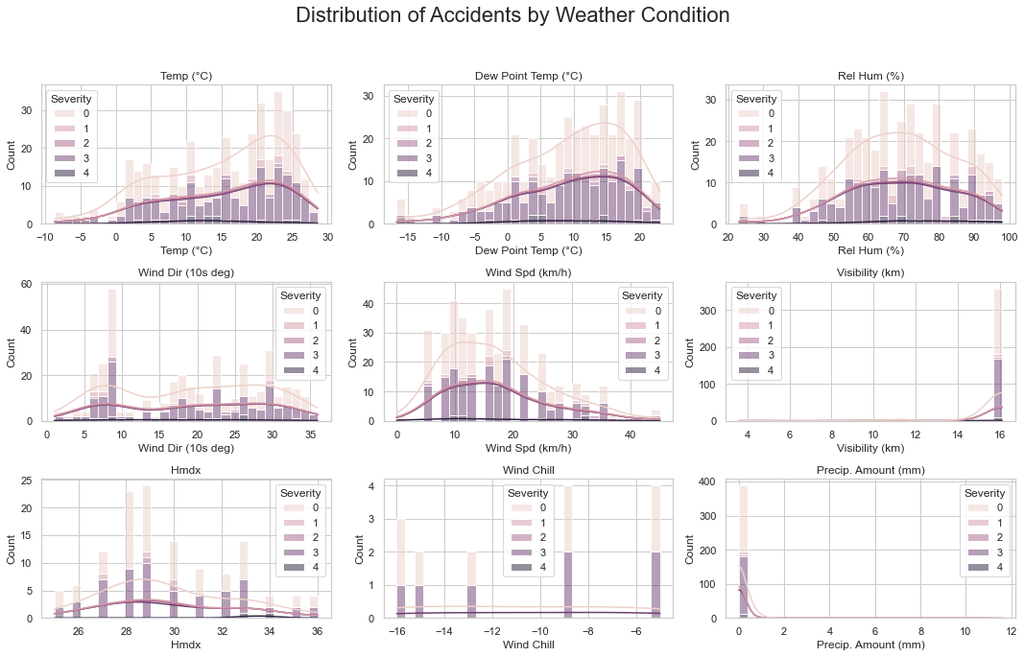

```python
import seaborn as sns
import matplotlib.pyplot as plt

# Assuming your DataFrame is named 'data_merged'
columns_to_plot = ['Temp (°C)', 'Dew Point Temp (°C)', 'Rel Hum (%)', 'Wind Dir (10s deg)',
                    'Wind Spd (km/h)', 'Visibility (km)', 'Hmdx', 'Wind Chill', 'Precip. Amount (mm)']

# Set the background style to 'whitegrid'
sns.set_theme(style="whitegrid")

# Create a 3x3 grid of subplots
fig, axes = plt.subplots(nrows=3, ncols=3, figsize=(15, 10))
fig.suptitle('Distribution of Accidents by Weather Condition', fontsize=22)

# Flatten the 2D array of subplots to a 1D array for easy iteration
axes = axes.flatten()

# Loop through each column and plot a histogram in a subplot
for i, column in enumerate(columns_to_plot):
    sns.histplot(x=column, hue='Severity', data=data_merged, multiple='stack', bins=30, kde=True, ax=axes[i])
    axes[i].set_title(column)
    axes[i].set_xlabel(column)
    axes[i].set_ylabel('Count')

# Adjust layout for better spacing
plt.tight_layout(rect=[0, 0.03, 1, 0.95])

plt.show()
```

## Correlation Matrix

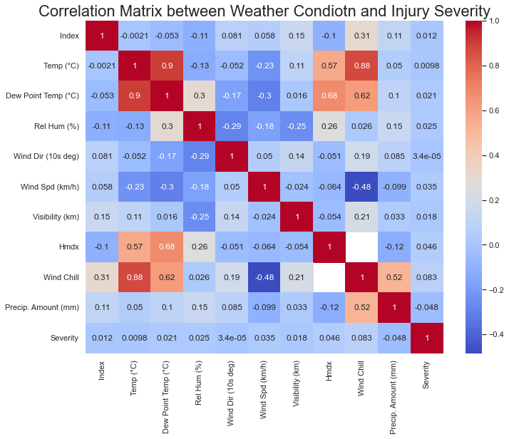

```python
import seaborn as sns
import matplotlib.pyplot as plt

# Assuming your DataFrame is named 'data_merged'
plt.figure(figsize=(10, 8))

# Set the background style to 'white'
sns.set_theme(style="white")

sns.heatmap(data_merged.corr(), annot=True, cmap='coolwarm')
plt.title('Correlation Matrix between Weather Condiotn and Injury Severity', fontsize=22)
plt.show()
```

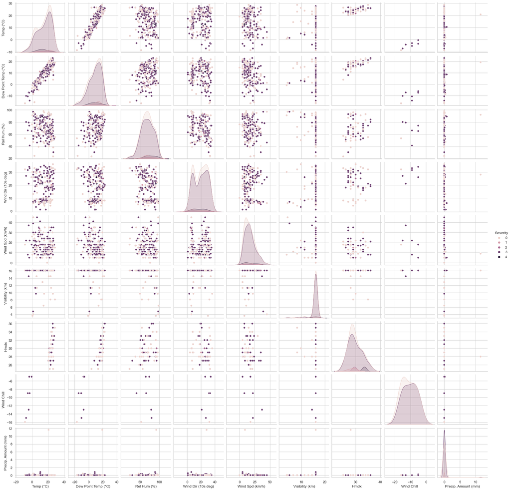

```python
import seaborn as sns
import matplotlib.pyplot as plt

# Assuming your DataFrame is named 'data_merged'
float_columns = data_merged.select_dtypes(include='float64')

# Set the background style to 'whitegrid'
sns.set_theme(style="whitegrid")

# Pairplot for all float64 columns against 'Severity'
sns.pairplot(pd.concat([float_columns, data_merged['Severity']], axis=1), hue='Severity')
plt.show()
```

## Distribution of Accidents by Weather

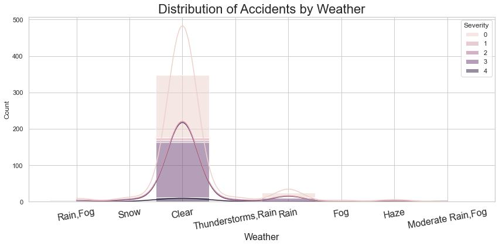

```python
import seaborn as sns
import matplotlib.pyplot as plt

plt.figure(figsize=(12, 6))
ax = sns.histplot(x='Weather', hue='Severity', data=data_merged, multiple='stack', bins=30, kde=True)
plt.title('Distribution of Accidents by Weather', fontsize=22)
plt.xlabel('Weather', fontsize=16)  # Set the font size for the x-axis label

# Rotate x-axis labels by 45 degrees
plt.xticks(rotation=10, fontsize=16)

plt.ylabel('Count')
sns.set_theme(style="whitegrid")
plt.tight_layout()  # Adjust layout for better spacing
plt.show()
```

# Check the correlation between the 'Severity' and weather

## One-way ANOVA tests

check the relationship between the 'Severity' and weather-related variables

```python
import pandas as pd
from scipy.stats import f_oneway

# Assuming data_merged is your DataFrame

# List to store P-values
p_values = []

# Selecting the target column (Severity)
target_column = 'Severity'

# Columns to check means with
columns_to_check = ['Temp (°C)', 'Dew Point Temp (°C)', 'Rel Hum (%)', 'Wind Dir (10s deg)','Hmdx',
                     'Wind Spd (km/h)', 'Visibility (km)', 'Wind Chill','Precip. Amount (mm)']

# Loop through each selected column
for column in columns_to_check:
    # Perform one-way ANOVA
    groups = [data_merged[data_merged[target_column] == level][column] for level in data_merged[target_column].unique()]

    _, p_value = f_oneway(*groups)

    # Appending the P-value to the list
    p_values.append((column, p_value))

# Creating a DataFrame from the P-values list
p_values_df = pd.DataFrame(p_values, columns=['Column', 'P-Value'])

# Displaying the DataFrame sorted by P-values
print(p_values_df.sort_values(by='P-Value'))
```

```
                Column   P-Value
3   Wind Dir (10s deg)  0.394733
2          Rel Hum (%)  0.398305
1  Dew Point Temp (°C)  0.836391
8  Precip. Amount (mm)  0.907393
0            Temp (°C)  0.923430
6      Visibility (km)  0.936185
5      Wind Spd (km/h)  0.972500
4                 Hmdx       NaN
7           Wind Chill       NaN
```

```python
import pandas as pd
from scipy.stats import f_oneway

# Assuming data_merged is your DataFrame

# Drop rows with NaN values in 'Hmdx' or 'Wind Chill'
data_cleaned = data_merged.dropna(subset=['Hmdx'])

# List to store P-values
p_values = []

# Selecting the target column (Severity)
target_column = 'Severity'

# Columns to check means with
columns_to_check = ['Hmdx']

# Loop through each selected column
for column in columns_to_check:
    # Perform one-way ANOVA
    groups = [data_cleaned[data_cleaned[target_column] == level][column] for level in data_cleaned[target_column].unique()]

    _, p_value = f_oneway(*groups)

    # Appending the P-value to the list
    p_values.append((column, p_value))

# Creating a DataFrame from the P-values list
p_values_df = pd.DataFrame(p_values, columns=['Column', 'P-Value'])

# Displaying the DataFrame sorted by P-values
print(p_values_df.sort_values(by='P-Value'))
```

```
  Column   P-Value
0   Hmdx  0.361769
```

```python
from scipy.stats import f_oneway

# Assuming data_merged is your DataFrame

# Drop rows with NaN values in 'Wind Chill'
data_cleaned = data_merged.dropna(subset=['Wind Chill'])

# List to store P-values
p_values = []

# Selecting the target column (Severity)
target_column = 'Severity'

# Columns to check means with
columns_to_check = ['Wind Chill']

# Loop through each selected column
for column in columns_to_check:
    # Perform one-way ANOVA
    groups = [data_cleaned[data_cleaned[target_column] == level][column] for level in data_cleaned[target_column].unique()]

    _, p_value = f_oneway(*groups)

    # Appending the P-value to the list
    p_values.append((column, p_value))

# Creating a DataFrame from the P-values list
p_values_df = pd.DataFrame(p_values, columns=['Column', 'P-Value'])

# Displaying the DataFrame sorted by P-values
print(p_values_df.sort_values(by='P-Value'))
```

```
       Column  P-Value
0  Wind Chill   0.7674
```

## Chi-squared test

To check the relationship between the 'Severity' column and the categorical variable 'Weather', can perform a chi-squared test. The chi-squared test can be used to assess whether there is a significant association between two categorical variables.

```python
import pandas as pd
from scipy.stats import chi2_contingency

# Assuming data_merged is your DataFrame

# Selecting the target column (Severity)
target_column = 'Severity'

# Selecting the categorical column (Weather Condition)
weather_condition_column = 'Weather'

# Creating a contingency table
contingency_table = pd.crosstab(data_merged[weather_condition_column], data_merged[target_column])

# Performing the chi-squared test
chi2, p_value, _, _ = chi2_contingency(contingency_table)

# Displaying the result
print(f"Chi-squared value: {chi2}")
print(f"P-value: {p_value}")
```

```
Chi-squared value: 32.79432819826731
P-value: 0.24340051655223682
```